# internship_report

Junhao Wang

26/05/2022

# Amber Community Data Analysis Program

### Abstract

This program is offered by Leanne Hyndman, the leader of Amber Community, and aims to find useful information through the available data provided by them or other contributors on the internet, and provide data-driven support.

The data is from three source: Amber Community, adsmapsdata, and the government’s website (https://www.coronavirus.vic.gov.au/victorian-coronavirus-covid-19-data)

### Background and Motivation

With the help and guidance of professor Rob Hyndman, I removed useless variables and cleaned the variable names and created the table referrals_clean1.

Then I checked the data type, name and value in each variable:

```
## Rows: 8,037
## Columns: 8
## $ x1                <dbl> 393, 14, 16, 73, 318, 254, 257, 18, 122, 138, 173, 2…
## $ referral_id       <dbl> 402, 18, 20, 77, 326, 261, 264, 22, 128, 144, 179, 2…
## $ date_received     <date> 2016-06-18, 2016-07-01, 2016-07-01, 2016-07-03, 201…
## $ date_entered      <date> 2016-08-19, 2016-07-04, 2016-07-05, 2016-07-04, 201…
## $ client_type       <chr> "driver", "driver", "driver", "driver", "injured pas…
## $ referred_by       <chr> "VPeR", "VPeR", "VPeR", "VPeR", "VPeR", "VPeR", "VPe…
## $ we_suggest_you_do <chr> NA, NA, NA, NA, NA, NA, NA, NA, NA, NA, NA, NA, NA, …
## $ postcode          <chr> NA, NA, NA, NA, NA, NA, NA, NA, NA, NA, NA, NA, NA, …
```

After checking that, I renamed the variable and combined the catogorical variables’ values and created referrals_clean2.

Next I created a new variable “day_of_week” to check whether more referrals are received on Monday

```
## # A tibble: 8 × 2
##   day_of_week proportion
##   <ord>            <dbl>
## 1 周日             11.0
## 2 周一             17.4
## 3 周二             15.6
## 4 周三             14.7
## 5 周四             15.0
## 6 周五             14.8
## 7 周六             10.3
## 8 <NA>              1.39
```

According to the table above, there are more referrals on Monday than on other days of week. This might be because that usually some referrals on weekend are postponed to the following day, which is Monday, and this can also explain why Tuesday has second largest amount of referrals, and the rest of the week days(Wednesday, Thursday and Friday) have about the same amount, which is still significantly larger(around 40%) than weekend.

We can also have a look at the summary of client type variable

```
## # A tibble: 9 × 2
##   client_type              n
##   <chr>                <int>
## 1 driver                2662
## 2 witness               2452
## 3 bereaved              1038
## 4 fam/fr of casualty     500
## 5 other injured person   428
## 6 passenger              428
## 7 unknown                272
## 8 rider                  241
## 9 other                   16
```

From the tabel above we can see that the major source of client is from driver, witness and bereaved people.

and referred_by variable

```
## # A tibble: 9 × 2
##   referred_by          n
##   <chr>            <int>
## 1 VPeR              6876
## 2 Self               409
## 3 VSA                223
## 4 unknown            196
## 5 TAC                191
## 6 Other               55
## 7 Family/friend       37
## 8 Police              35
## 9 Victims of Crime    15
```

#### time related analysis

[figure not shown]

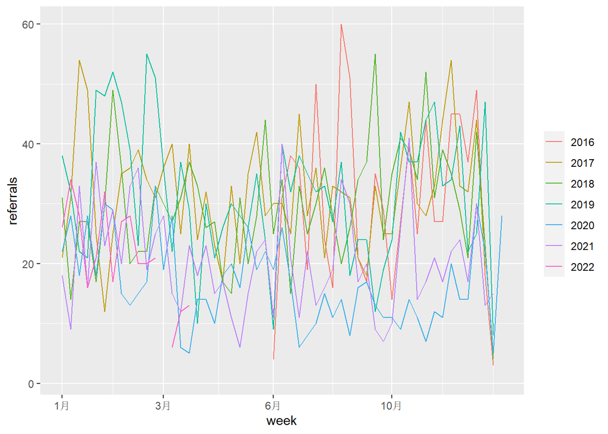

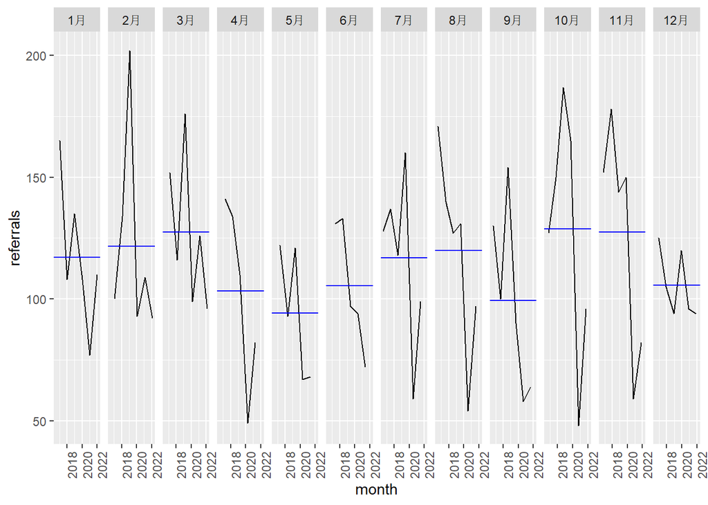

From the plot above we can see that almost for every month there is a significant drop in year 2020, which can be the consequence of Australia’s lock-down policy for COVID-19.

```
## Series: referrals
## Model: ETS(M,N,N)
##   Smoothing parameters:
##     alpha = 0.3389616
##
##   Initial states:
##      l[0]
##  134.8555
##
##   sigma^2:  0.0609
##
##      AIC     AICc      BIC
## 755.0811 755.4503 761.7834
```

This graph shows subseries of the referrals data by month. As is shown above the peaks in term of number of referrals are in March and October, and the troughs are in May and Sep. Most months show a downward trend from 2017 to 2022 but have troughs in 2020 or 2021, which may be a consequence of covid-19. But overall the seasonality is week as the ETC function suggests an MNN model which does not contain seasonal component.

Maybe the drop in the 2nd quarter is because the staff in the organization usually have a vocation due to the cold weather in 2nd quarter

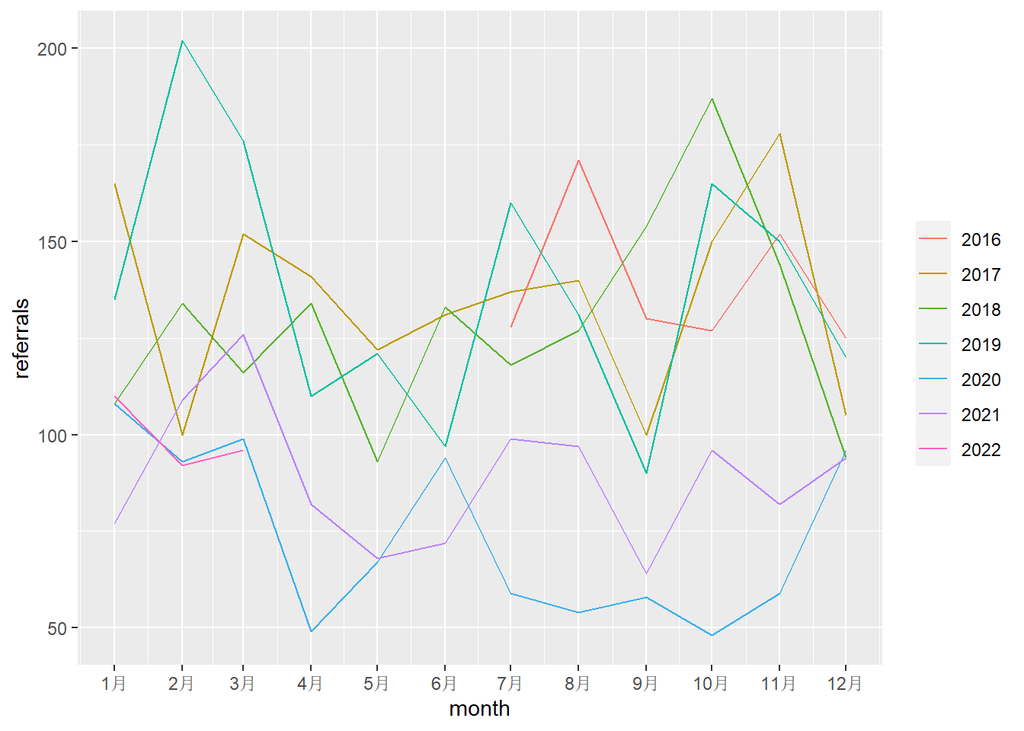

From the graph above we can observe that the seasonality seems to be not very strong. But I also notice that the number of referrals usually drops in September, which may be due to the cold weather since staff are likely to go on a vocation to somewhere warm during this time.

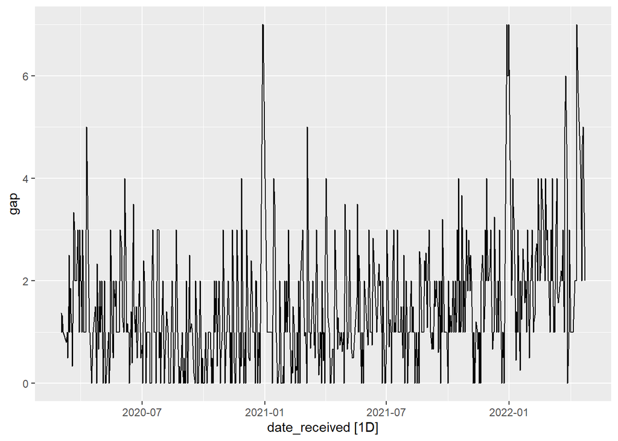

Although not very apparent, we can still observe the downward pattern followed by a upwards pattern in this gap plot, conbining with the drop of refferals after the outbreak of covid-19, we can infer that the number of referrals does to some degree influenced the speed of processing referrals, and this indicates that the workload might be close to the upper limit of RTSSV.

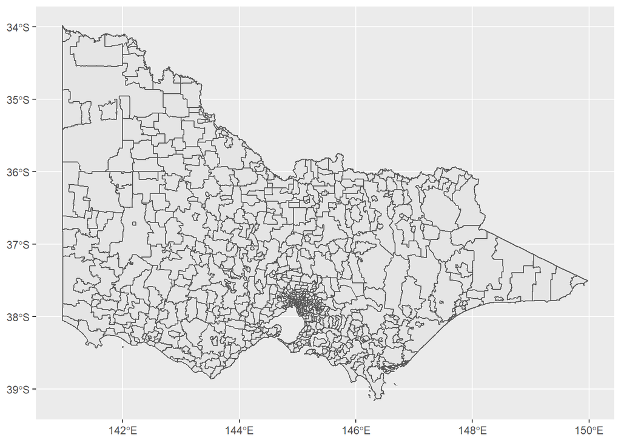

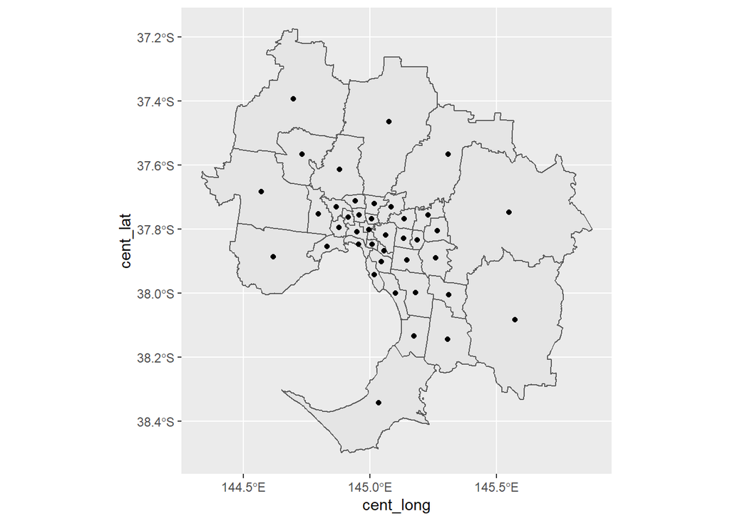

```
## Simple feature collection with 40 features and 11 fields
## Geometry type: MULTIPOLYGON
## Dimension:     XY
## Bounding box:  xmin: 144.3336 ymin: -38.49885 xmax: 145.8784 ymax: -37.1751
## Geodetic CRS:  WGS 84
## First 10 features:
##     sa3_code_2016      sa3_name_2016 sa4_code_2016          sa4_name_2016
## 112         20601 Brunswick - Coburg           206      Melbourne - Inner
## 113         20602    Darebin - South           206      Melbourne - Inner
## 114         20603           Essendon           206      Melbourne - Inner
## 115         20604     Melbourne City           206      Melbourne - Inner
## 116         20605       Port Phillip           206      Melbourne - Inner
## 117         20606 Stonnington - West           206      Melbourne - Inner
## 118         20607              Yarra           206      Melbourne - Inner
## 119         20701         Boroondara           207 Melbourne - Inner East
```

[output cut: 24 more lines]

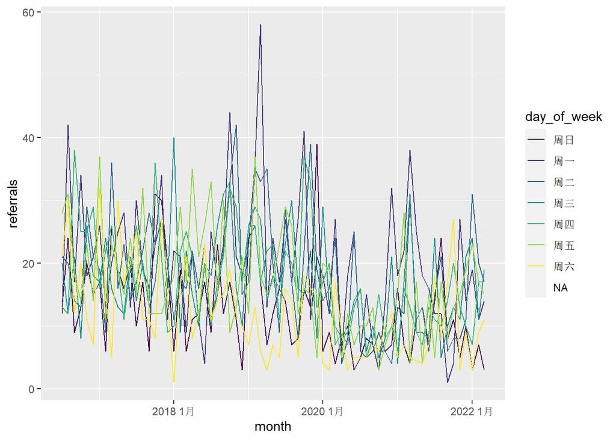

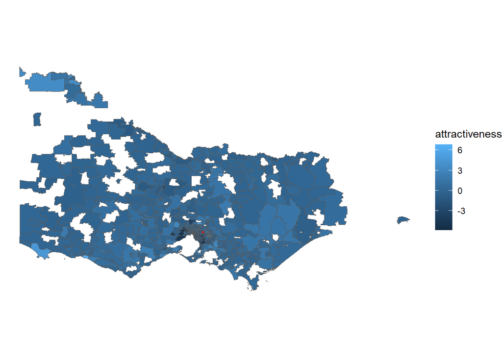

[interactive chart not shown]